# Growth-Driven or Redistributive? An Analysis of Chicago’s TIF Spending

Author

Yiduo Pan | Section: T Th 11:00-12:20 | GitHub: YiduoPan5664

Published

March 9, 2026

```python
import os
import pandas as pd
import geopandas as gpd
from shapely import wkt
import matplotlib.pyplot as plt
import matplotlib.patches as mpatches
import numpy as np

os.makedirs("figures", exist_ok=True)
```

## Research Question

Chicago’s Tax Increment Financing (TIF) program is designed to attract investment and support redevelopment in economically distressed neighbourhoods. When a TIF district is created, the property-tax level in that area is frozen at a baseline. As property tax rises, the additional tax revenue above that baseline is called the **tax increment**, and is retained inside the district to fund redevelopment.

In principle, this system should help channel public investment toward neighbourhoods with greater economic need. However, critics often argue that TIF districts benefit areas that are already experiencing growth. In that case, the program may reinforce existing inequalities rather than reduce them.

Therefore, this project asks: **is Chicago’s TIF spending growth-driven or reditributive?**

## Data & Approach

This analysis combines two main datasets, the Chicago TIF Annual Reports that provide yearly expenditure information for every TIF district in the city and the ACS 5-year community area data from the Chicago Data Portal that provides household income distributions for each of Chicago’s 77 community areas. To map these districts, I merge the current TIF boundary file with a deprecated boundary dataset that includes districts repealed before March 2018.

To examine whether TIF spending is related to neighborhood income, I first compare total TIF expenditure across districts with the income levels of the communities where they are located. I then normalize the total TIF spending by the cumulative tax increment generated by each district to check whether the higher TIF spending is driven by higher tax revenue or by differences in how spending is distributed.

```python
import re

# ── File paths ─────────────────────────────────────────────────────────────────
TIF_ANNUAL  = "data/raw-data/Tax_Increment_Financing_(TIF)_Annual_Report_-_Analysis_of_Special_Tax_Allocation_Fund_20260301.csv"
TIF_BOUNDS  = "data/raw-data/Boundaries_-_Tax_Increment_Financing_Districts_20260301.csv"
TIF_DEP     = "data/raw-data/Boundaries_-_Tax_Increment_Financing_Districts_(Deprecated_March_2018)_20260301.csv"
COMM_BOUNDS = "data/raw-data/Boundaries_-_Community_Areas_20260301.csv"
ACS_INCOME  = "data/raw-data/ACS_5_Year_Data_by_Community_Area_20260301.csv"

def clean_dollars(s):
    return pd.to_numeric(s.astype(str).str.replace(r"[$,]", "", regex=True), errors="coerce")

def normalize_ref(s):
    """Normalise 'T- 87' and 'T-087' both to 'T-87'."""
    return re.sub(r"T-\s*0*", "T-", str(s).strip())

# ── 1. TIF annual expenditures ─────────────────────────────────────────────────
tif_raw = pd.read_csv(TIF_ANNUAL)
tif_raw.columns = tif_raw.columns.str.strip()
tif_raw["Total Expenditure"] = clean_dollars(tif_raw["Total Expenditure"])
tif_raw["Report Year"]       = pd.to_numeric(tif_raw["Report Year"], errors="coerce")
tif_raw["tif_id"]            = tif_raw["TIF Number"].apply(normalize_ref)

# Last reported cumulative increment (avoids summing negative annual adjustments)
tif_raw["Property Tax Increment - Cumulative"] = clean_dollars(
    tif_raw["Property Tax Increment - Cumulative"]
)
inc_last = (
    tif_raw.dropna(subset=["Property Tax Increment - Cumulative"])
    .sort_values("Report Year")
    .groupby("tif_id", as_index=False)["Property Tax Increment - Cumulative"]
    .last()
    .rename(columns={"Property Tax Increment - Cumulative": "cumulative_increment"})
)
tif_cumulative = (
    tif_raw.groupby("tif_id", as_index=False)
    .agg(cumulative_expenditures=("Total Expenditure", "sum"))
    .merge(inc_last, on="tif_id", how="left")
)
tif_cumulative["exp_per_increment"] = (
    tif_cumulative["cumulative_expenditures"] / tif_cumulative["cumulative_increment"]
).replace([float("inf"), float("-inf")], float("nan"))

# ── 2. TIF boundaries — combine current + deprecated ──────────────────────────
b1 = pd.read_csv(TIF_BOUNDS); b1.columns = b1.columns.str.strip()
b2 = pd.read_csv(TIF_DEP);   b2.columns = b2.columns.str.strip()
for df in [b1, b2]:
    df["tif_id"] = df["REF"].apply(normalize_ref)
tif_bounds = (
    pd.concat([b1[["NAME","tif_id","the_geom"]], b2[["NAME","tif_id","the_geom"]]])
    .drop_duplicates("tif_id")
)
tif_bounds["geometry"] = tif_bounds["the_geom"].apply(wkt.loads)
tif_geo = gpd.GeoDataFrame(tif_bounds, geometry="geometry", crs="EPSG:4326")
tif_geo = tif_geo.rename(columns={"NAME": "TIF District"})

tif = tif_geo.merge(tif_cumulative, on="tif_id", how="left")

# ── 3. Community area boundaries ──────────────────────────────────────────────
comm_raw = pd.read_csv(COMM_BOUNDS)
comm_raw["geometry"] = comm_raw["the_geom"].apply(wkt.loads)
comm_geo = gpd.GeoDataFrame(comm_raw, geometry="geometry", crs="EPSG:4326")
comm_geo = comm_geo.rename(columns={"COMMUNITY": "Community Area"})
comm_geo["Community Area"] = comm_geo["Community Area"].str.upper().str.strip()

# ── 4. ACS income data ─────────────────────────────────────────────────────────
acs_raw = pd.read_csv(ACS_INCOME)
acs_raw.columns = acs_raw.columns.str.strip()
acs_latest = acs_raw.sort_values("ACS Year").groupby("Community Area").last().reset_index()
acs_latest["Community Area"] = acs_latest["Community Area"].str.upper().str.strip()

income_cols = ["Under $25,000", "$25,000 to $49,999",
               "$50,000 to $74,999", "$75,000 to $125,000", "$125,000 +"]
midpoints   = [12500, 37500, 62500, 100000, 175000]
for col in income_cols:
    acs_latest[col] = pd.to_numeric(acs_latest[col].astype(str).str.replace(",", ""), errors="coerce")
acs_latest["total_hh"]       = acs_latest[income_cols].sum(axis=1)
acs_latest["weighted_income"] = (
    sum(acs_latest[col] * mid for col, mid in zip(income_cols, midpoints))
    / acs_latest["total_hh"]
)
comm = comm_geo.merge(
    acs_latest[["Community Area", "weighted_income", "total_hh"]],
    on="Community Area", how="left"
)
```

## Static Visualisations

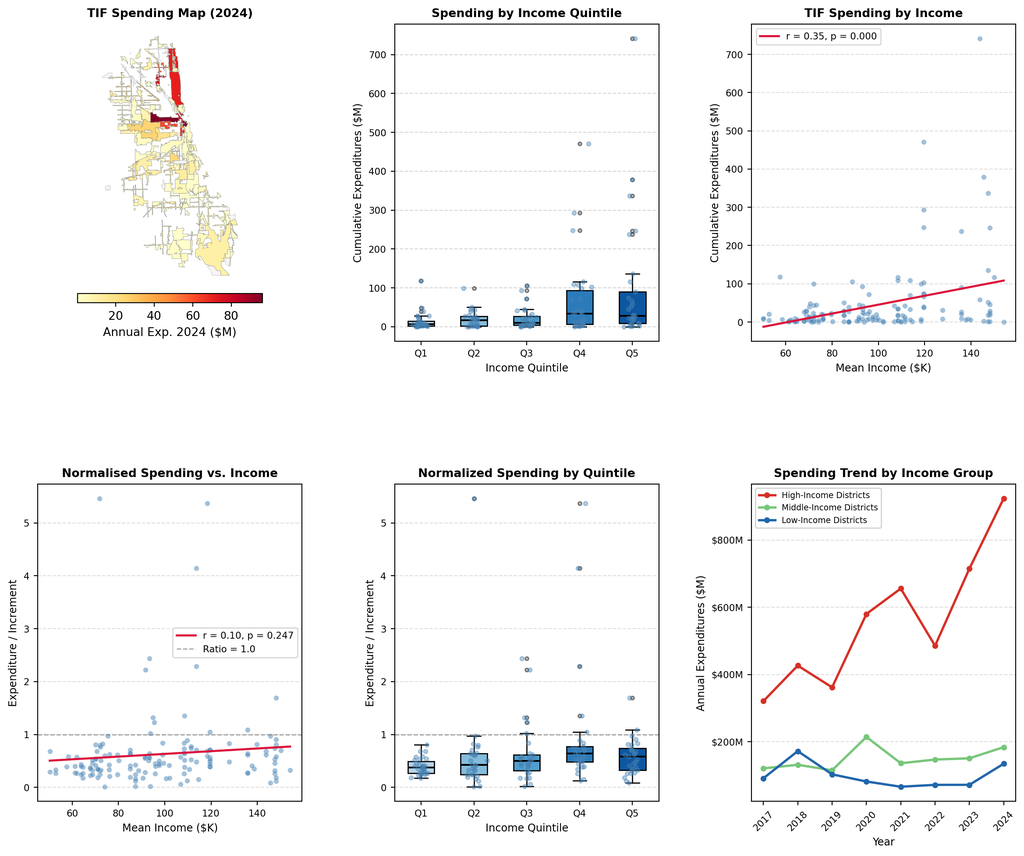

```python
from scipy import stats
import matplotlib.ticker as mticker

YEAR = 2024

# Prep: annual expenditure for map
tif_annual_year = (
    tif_raw[tif_raw["Report Year"] == YEAR]
    .groupby("tif_id", as_index=False)
    .agg(annual_expenditure=("Total Expenditure", "sum"))
)
tif_year  = tif.merge(tif_annual_year, on="tif_id", how="left")
tif_plot  = tif_year.dropna(subset=["annual_expenditure"]).copy()
tif_plot["expenditure_m"] = tif_plot["annual_expenditure"] / 1e6
p99 = tif_plot["expenditure_m"].quantile(0.99)
tif_plot["expenditure_m_clipped"] = tif_plot["expenditure_m"].clip(upper=p99)

# Prep: spatial join
tif_centroids = tif.copy()
tif_centroids["geometry"] = tif.geometry.centroid
joined = gpd.sjoin(
    tif_centroids[["tif_id", "TIF District", "cumulative_expenditures",
                   "exp_per_increment", "geometry"]],
    comm[["Community Area", "weighted_income", "geometry"]],
    how="left", predicate="within",
).dropna(subset=["weighted_income", "cumulative_expenditures"])
joined["quintile"] = pd.qcut(
    joined["weighted_income"], q=5, labels=["Q1", "Q2", "Q3", "Q4", "Q5"],
)
quintile_order = ["Q1", "Q2", "Q3", "Q4", "Q5"]
groups = [joined.loc[joined["quintile"] == q, "cumulative_expenditures"].dropna() / 1e6
          for q in quintile_order]
blues = plt.cm.Blues(np.linspace(0.3, 0.85, 5))

scatter_data = joined.copy()
scatter_data["exp_m"]    = scatter_data["cumulative_expenditures"] / 1e6
scatter_data["income_k"] = scatter_data["weighted_income"] / 1000
slope, intercept, r, p_val, _ = stats.linregress(scatter_data["income_k"], scatter_data["exp_m"])
x_line = np.linspace(scatter_data["income_k"].min(), scatter_data["income_k"].max(), 200)
y_line = intercept + slope * x_line

# Prep: normalize data
norm_data = joined.dropna(subset=["exp_per_increment", "weighted_income"]).copy()
norm_data = norm_data[norm_data["exp_per_increment"] < 10]
norm_data["income_k"] = norm_data["weighted_income"] / 1000
slope_n, intercept_n, r_n, p_n, _ = stats.linregress(
    norm_data["income_k"], norm_data["exp_per_increment"]
)
x_n = np.linspace(norm_data["income_k"].min(), norm_data["income_k"].max(), 200)
y_n = intercept_n + slope_n * x_n
norm_data["quintile_n"] = pd.qcut(
    norm_data["weighted_income"], q=5, labels=["Q1", "Q2", "Q3", "Q4", "Q5"],
)
groups_n = [norm_data.loc[norm_data["quintile_n"] == q, "exp_per_increment"].dropna()
            for q in quintile_order]

# Prep: time trend
income_lookup = joined[["tif_id", "weighted_income"]].drop_duplicates("tif_id")
tif_trend = tif_raw.merge(income_lookup, on="tif_id", how="inner")
tif_trend = tif_trend.dropna(subset=["weighted_income", "Total Expenditure", "Report Year"])
breaks = tif_trend["weighted_income"].quantile([0, 1/3, 2/3, 1]).values
tif_trend["income_group"] = pd.cut(
    tif_trend["weighted_income"], bins=breaks, include_lowest=True,
    labels=["Low-Income Districts", "Middle-Income Districts", "High-Income Districts"]
)
annual = (
    tif_trend.groupby(["Report Year", "income_group"])["Total Expenditure"]
    .sum().reset_index()
)
pivot = annual.pivot(index="Report Year", columns="income_group", values="Total Expenditure")
trend_years = sorted(pivot.index.astype(int))
group_colors = {
    "Low-Income Districts":    "#2166ac",
    "Middle-Income Districts": "#78c679",
    "High-Income Districts":   "#d73027",
}

# Draw 2×3 grid
fig = plt.figure(figsize=(15, 12))
gs  = fig.add_gridspec(2, 3, hspace=0.45, wspace=0.35)

# Row 1
# R1C1 — map
ax = fig.add_subplot(gs[0, 0])
tif_year.plot(ax=ax, color="whitesmoke", edgecolor="silver", linewidth=0.3, zorder=1)
tif_plot.plot(
    column="expenditure_m_clipped", ax=ax, cmap="YlOrRd",
    edgecolor="grey", linewidth=0.2, legend=True,
    legend_kwds={"label": f"Annual Exp. {YEAR} ($M)", "orientation": "horizontal",
                 "shrink": 0.7, "pad": 0.02},
    zorder=2,
)
ax.set_title(f"TIF Spending Map ({YEAR})", fontsize=10, fontweight="bold")
ax.set_axis_off()

# R1C2 — absolute boxplot
ax = fig.add_subplot(gs[0, 1])
bp = ax.boxplot(groups, labels=quintile_order, patch_artist=True,
                medianprops={"color": "black", "linewidth": 1.5},
                flierprops={"marker": "o", "markersize": 3,
                            "markerfacecolor": "grey", "alpha": 0.5},
                whiskerprops={"linewidth": 1}, capprops={"linewidth": 1})
for patch, color in zip(bp["boxes"], blues):
    patch.set_facecolor(color)
for i, grp in enumerate(groups, start=1):
    ax.scatter(np.random.normal(i, 0.07, size=len(grp)), grp,
               alpha=0.4, s=12, color="steelblue", zorder=3)
ax.set_xlabel("Income Quintile", fontsize=9)
ax.set_ylabel("Cumulative Expenditures ($M)", fontsize=9)
ax.set_title("Spending by Income Quintile", fontsize=10, fontweight="bold")
ax.yaxis.grid(True, linestyle="--", alpha=0.5)
ax.set_axisbelow(True)
ax.tick_params(labelsize=8)

# R1C3 — absolute scatter
ax = fig.add_subplot(gs[0, 2])
ax.scatter(scatter_data["income_k"], scatter_data["exp_m"],
           alpha=0.5, s=20, color="steelblue", edgecolors="white", linewidths=0.3)
ax.plot(x_line, y_line, color="crimson", linewidth=1.8,
        label=f"r = {r:.2f}, p = {p_val:.3f}")
ax.set_xlabel("Mean Income ($K)", fontsize=9)
ax.set_ylabel("Cumulative Expenditures ($M)", fontsize=9)
ax.set_title("TIF Spending by Income", fontsize=10, fontweight="bold")
ax.legend(fontsize=8)
ax.yaxis.grid(True, linestyle="--", alpha=0.4)
ax.set_axisbelow(True)
ax.tick_params(labelsize=8)

# Row 2
# R2C1 — normalized scatter
ax = fig.add_subplot(gs[1, 0])
ax.scatter(norm_data["income_k"], norm_data["exp_per_increment"],
           alpha=0.5, s=20, color="steelblue", edgecolors="white", linewidths=0.3)
ax.plot(x_n, y_n, color="crimson", linewidth=1.8,
        label=f"r = {r_n:.2f}, p = {p_n:.3f}")
ax.axhline(1.0, color="grey", linestyle="--", linewidth=1, alpha=0.7, label="Ratio = 1.0")
ax.set_xlabel("Mean Income ($K)", fontsize=9)
ax.set_ylabel("Expenditure / Increment", fontsize=9)
ax.set_title("Normalised Spending vs. Income", fontsize=10, fontweight="bold")
ax.legend(fontsize=8)
ax.yaxis.grid(True, linestyle="--", alpha=0.4)
ax.set_axisbelow(True)
ax.tick_params(labelsize=8)

# R2C2 — normalised boxplot
ax = fig.add_subplot(gs[1, 1])
bp_n = ax.boxplot(groups_n, labels=quintile_order, patch_artist=True,
                  medianprops={"color": "black", "linewidth": 1.5},
                  flierprops={"marker": "o", "markersize": 3,
                              "markerfacecolor": "grey", "alpha": 0.5},
                  whiskerprops={"linewidth": 1}, capprops={"linewidth": 1})
for patch, color in zip(bp_n["boxes"], blues):
    patch.set_facecolor(color)
for i, grp in enumerate(groups_n, start=1):
    ax.scatter(np.random.normal(i, 0.07, size=len(grp)), grp,
               alpha=0.4, s=12, color="steelblue", zorder=3)
ax.axhline(1.0, color="grey", linestyle="--", linewidth=1, alpha=0.7)
ax.set_xlabel("Income Quintile", fontsize=9)
ax.set_ylabel("Expenditure / Increment", fontsize=9)
ax.set_title("Normalized Spending by Quintile", fontsize=10, fontweight="bold")
ax.yaxis.grid(True, linestyle="--", alpha=0.4)
ax.set_axisbelow(True)
ax.tick_params(labelsize=8)

# R2C3 — time trend
ax = fig.add_subplot(gs[1, 2])
for grp in ["High-Income Districts", "Middle-Income Districts", "Low-Income Districts"]:
    if grp in pivot.columns:
        ax.plot(pivot.index.astype(int), pivot[grp] / 1e6,
                label=grp, color=group_colors[grp],
                linewidth=2, marker="o", markersize=4)
ax.set_xlabel("Year", fontsize=9)
ax.set_ylabel("Annual Expenditures ($M)", fontsize=9)
ax.set_title("Spending Trend by Income Group", fontsize=10, fontweight="bold")
ax.legend(fontsize=7, framealpha=0.9)
ax.yaxis.set_major_formatter(mticker.FuncFormatter(lambda x, _: f"${x:,.0f}M"))
ax.yaxis.grid(True, linestyle="--", alpha=0.4)
ax.set_axisbelow(True)
ax.set_xticks(trend_years)
ax.set_xticklabels(trend_years, rotation=45, fontsize=7)
ax.tick_params(labelsize=8)

plt.savefig("figures/fig_all.png", dpi=150, bbox_inches="tight")
plt.show()
```

Row 1 — Left: TIF spending map (2024). Centre: cumulative expenditure by income quintile. Right: cumulative expenditure by income.

Row 2 — Left: normalized spending by income. Centre: normalized spending by quintile. Right: annual spending trend 2017–2024.

**Normalised spending.** Once spending is divided by tax increment, the relationship between income and spending becomes much weaker(r = 0.10, p = 0.247). Wealthier districts spend more in absolute terms only because they generate more tax increment. The trend chart shows the absolute gap has nonetheless grown from roughly 3× to 6× between 2017 and 2024.

## Streamlit App

The interactive dashboard (`streamlit-app/app.py`) is designed for policymakers and city officials evaluating whether Chicago’s TIF program is meeting its redistributive goals. The dashboard is deployed at https://final-project-group41.streamlit.app/ and contains five tabs:

- **District Map**: Switch between *Annual Expenditure*, *Community Income*, and *Normalised Spending* views, with a year slider.
- **Spending by Neighbourhood Income**: Boxplot of cumulative TIF expenditure across five income quintiles.
- **Does Income Predict Spending?**: Scatter plot with OLS trend line (r = 0.35, p < 0.001).
- **Is the Gap Fair? (Normalised View)**: Scatter and boxplot for the normalised ratio (r = 0.10, p = 0.247).
- **Is the Gap Growing?**: Line chart of annual expenditure by income tertile, 2017–2024.

## Conclusion

Taken together, the results suggest that Chicago’s TIF system does not strongly direct spending toward lower-income neighbourhoods. In raw terms, districts located in higher-income areas tend to receive more expenditure.

However, the normalized analysis provides an important clarification. Once spending is compared to the tax increment each district generates, the gap becomes much smaller, indicating that the pattern is largely driven by the financing structure of the program.

The spending difference between high- and low-income districts increased from about 3× to 6× between 2017 and 2024, suggesting that the disadvantage for lower-income communities may be intensifying.

## Limitations

The income measure is an approximation: I assign midpoint values to ACS bracket counts rather than using continuous income data, which may introduce measurement error. Another limitation is that this analysis focuses on total spending at the district level, and does not examine how TIF are distributed within districts.